# HW 2: Маркетинговая кампания

Егоров Кирилл, ksegorov

## Задача

Франчайзи нашей продуктовой сети из соседнего региона решил провести маркетинговую кампанию. Для этого он запросил у нас ответы на интересующие его вопросы для запуска таргетированной рекламы в социальных сетях. Необходимо ответить на указанные вопросы и предсказать отклик рекламной кампании франчайзи, таргетированной на его клиентов по указанным им переменным.

### Загрузка данных и преобразование

```r
marketing = read.csv("marketing_campaign.csv")
library(tidyverse)
library(rpart)
library(rpart.plot)
```

```r
# преобразование данных, предобработка
marketing = marketing %>%
  mutate(Response = ifelse(Response == 0, "Клиент не откликнулся", "Клиент откликнулся"))
marketing = dplyr::rename(marketing, 'Траты на вино' = MntWines)
marketing = dplyr::rename(marketing, 'Отклик на кампанию' = Response)
marketing = rename(marketing,'Семейное положение' = Marital_Status)
marketing2 = marketing
marketing3 = marketing
marketing4 = marketing
marketing5 = marketing
```

### Исследовательские вопросы и тесты

#### Вопрос 1

**Вопрос:** Есть ли связь между готовность клиента откликнуться на кампанию с тем, сколько клиент потратил на вино?

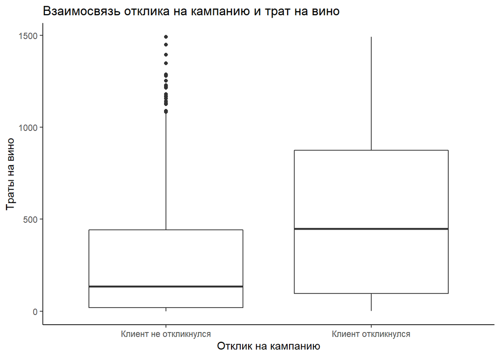

```r
### Разведывательный анализ
marketing$`Отклик на кампанию` = as.factor(marketing$`Отклик на кампанию`)
library(ggplot2)
ggplot(data = marketing) +
  geom_boxplot(aes(x = `Отклик на кампанию`, y = `Траты на вино`)) +
  scale_fill_brewer(palette="Set2") +
  theme(panel.grid.major = element_blank(), panel.grid.minor = element_blank(),
panel.background = element_blank(), axis.line = element_line(colour = "black"))  +
  ggtitle("Взаимосвязь отклика на кампанию и трат на вино")
```

```r
### Стат тест
t.test(`Траты на вино` ~ `Отклик на кампанию`, data = marketing)
```

```
##
##  Welch Two Sample t-test
##
## data:  Траты на вино by Отклик на кампанию
## t = -9.3537, df = 453.02, p-value < 2.2e-16
## alternative hypothesis: true difference in means between group Клиент не откликнулся and group Клиент откликнулся is not equal to 0
## 95 percent confidence interval:
##  -286.4377 -186.9735
## sample estimates:
## mean in group Клиент не откликнулся    mean in group Клиент откликнулся
##                            265.9980                            502.7036
```

**Ответ:** Существует статистическая взаимосвязь между откликом на маркетинговую кампанию и тратами клиента на вино за последние 2 года. У клиентов, которые откликнулись на кампанию, в среднем траты на вино статистически значимо выше на 236,7 ед.

**Вывод:** Была сфорулирована нулевая гипотеза о том, что взаимосвязи между переменными `Траты на вино` и `Отклик на кампанию` нет. По результатам теста Стьюдента, а именно: p-value 2.2e-16 < 0.05, нулевая гипотеза была отвергнута и была принята альтернативная, что взаимосвязь между данными переменными существует.

#### Вопрос 2

**Вопрос:** Есть ли взаимосвязь между откликом клиентов на маркетинговую кампанию и долей товаров, купленных клиентами по скидкам?

```r
### Преобразования
marketing2 = marketing
marketing2 = marketing2 %>%
  mutate(percent = NumDealsPurchases/(NumWebPurchases + NumStorePurchases + NumDealsPurchases))
### Разведуем агрегацией
for_graph = group_by(marketing2, `Отклик на кампанию`)
for_graph = for_graph %>%
  filter(percent > 0) %>%
  summarise(count = mean(percent))

### Строим график
graphik = ggplot(data = for_graph, aes(x = `Отклик на кампанию`, y = count))  +
  geom_bar(stat = "identity") +
 theme(panel.grid.major = element_blank(), panel.grid.minor = element_blank(),
panel.background = element_blank(), axis.line = element_line(colour = "black"))

### Стат. тест
t.test(percent ~`Отклик на кампанию`, data = marketing2)
```

```
##
##  Welch Two Sample t-test
##
## data:  percent by Отклик на кампанию
## t = 3.4698, df = 520.95, p-value = 0.0005641
## alternative hypothesis: true difference in means between group Клиент не откликнулся and group Клиент откликнулся is not equal to 0
## 95 percent confidence interval:
##  0.01214223 0.04383664
## sample estimates:
## mean in group Клиент не откликнулся    mean in group Клиент откликнулся
##                           0.2111059                           0.1831164
```

**Ответ:** Существует статистическая взаимосвязь между откликом клиентов на маркетинговую кампанию и долей товаров, купленных клиентами по скидкам. У клиентов, которые не откликнулись на кампанию, в среднем доля таких товаров статистически значимо выше на 0,0279895 ед или 2,8% процентных пункта.

**Вывод:** Была сфорулирована нулевая гипотеза о том, что взаимосвязи между переменными `percent`(доля товаров по скидке) и `Отклик на кампанию` нет. По результатам теста Стьюдента, а именно: p-value 0.0005641 < 0.05, нулевая гипотеза была отвергнута и была принята альтернативная, что взаимосвязь между данными переменными существует.

#### Вопрос 3

**Вопрос:** Есть ли взаимосвязь между откликом клиентов на маркетинговую кампанию и их семейным статусом?

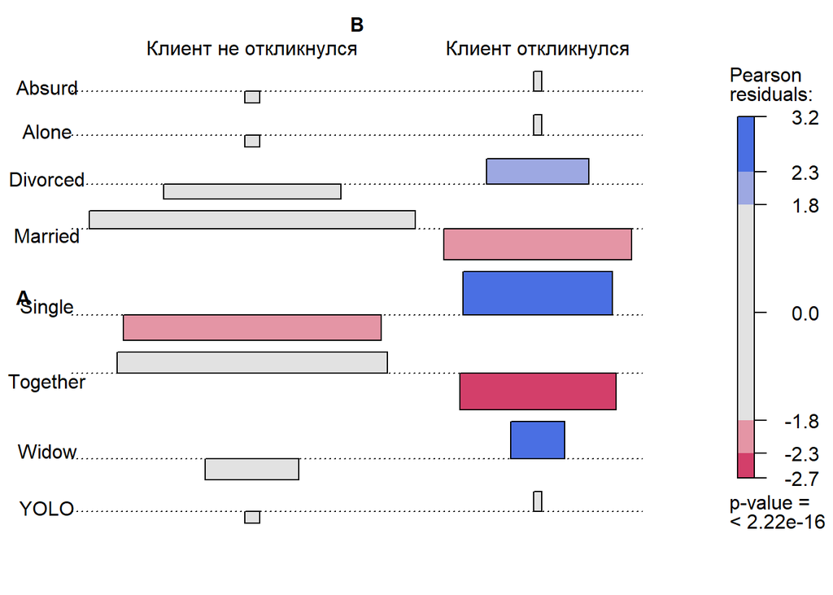

```r
marketing4$`Отклик на кампанию` = as.factor(marketing4$`Отклик на кампанию`)
marketing4$`Семейное положение` = as.factor(marketing4$`Семейное положение`)
marketing4_1 = filter(marketing4, marketing4$`Семейное положение` != "YOLO")
marketing4_1 = filter(marketing4, marketing4$`Семейное положение` != "Alone")
marketing4_1 = filter(marketing4, marketing4$`Семейное положение` != "Absurd")
library(vcd)

assoc(table(marketing4$`Семейное положение`, marketing4$`Отклик на кампанию`), gp=shading_max,
      rot_labels = c(0, 0, 0, 0),
      rot_varnames = c(0, 0, 0, 0), na.rm = TRUE)
```

```r
### Стат. тест
chisq.test(marketing4_1$`Семейное положение`, marketing4_1$`Отклик на кампанию` )
```

```
##
##  Pearson's Chi-squared test
##
## data:  marketing4_1$`Семейное положение` and marketing4_1$`Отклик на кампанию`
## X-squared = 51.614, df = 6, p-value = 2.229e-09
```

**Ответ:** Существует статистическая взаимосвязь между откликом клиентов на маркетинговую кампанию и семейным положением клиентов. Клиенты, которые имеют семейный статус Divorced, Single, Widow, статистически значимо чаще откликались на маркетинговые кампании. Клиенты, которые имеют семейный статус Married, Together, статистически значимо реже откликались на приемную кампанию.

**Вывод:** Была сфорулирована нулевая гипотеза о том, что взаимосвязи между переменными `Семеное положение` и `Отклик на кампанию` нет. По результатам теста Хи-Квадрат, а именно: p-value = 2.229e-09 < 0.05, нулевая гипотеза была отвергнута и была принята альтернативная, что взаимосвязь между данными переменными существует.

### Предсказание отклика на кампанию

Заказчиком была поставлена задача предсказать отклик на его кампанию по указанным им переменным: `Семейное положение`, `percent`(доля товаров по скидке), `Траты на вино`. На основании этого было построено дерево решений, которое имело 5 разбиений. Следующим шагом дерево было обрезано до 1 разбиеня (Предсказание по переменной `Траты на вино`) по complexity parameter = 0.018519, поскольку при этом значении cp наблюдается минимальная ошибка xerror(0.96667). Точность модели была рассчитана по обучающей и тестовой выборке как до отрезания дерева, так и после. Последний предсказанный отклик на тестовой выборке по Accuracy = 0.7902622 или 79%. Accuracy модели в обоих случаях была больше на тестовой выборке 80% > 78% и 79% > 76% соответственно. Полученные значения Accuracy говорят о том, что точность по тестовым выборкам в пределах изначального значения точности, даже лучше. Следовательно, можно говорить о удовлетворительном качестве модели и отсутствии переобучения.

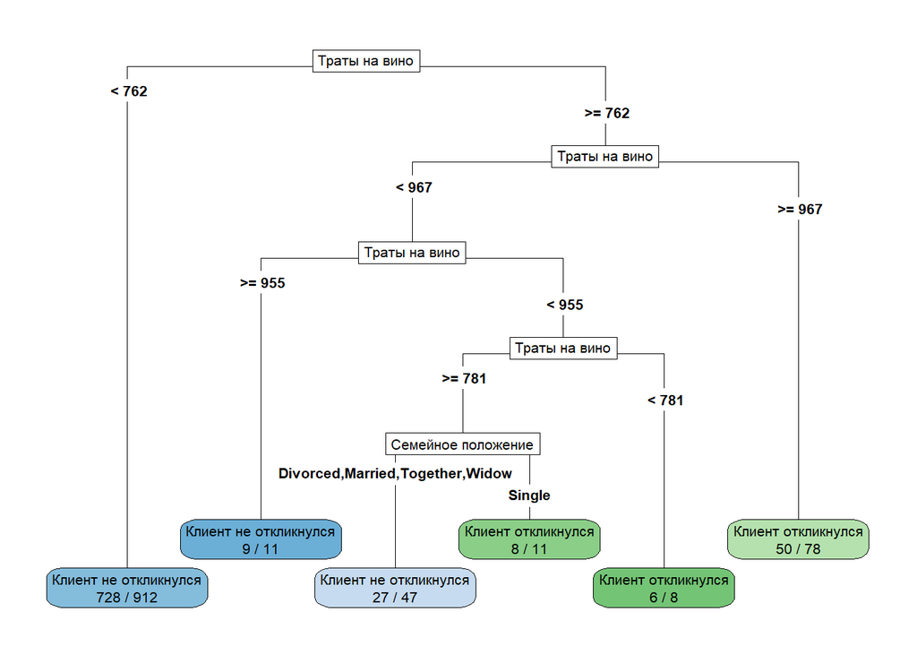

```r
marketing3 = dplyr::rename(marketing2, 'Доля покупок по скидкам' = percent)
### Дерево
# Делим выборки
set.seed(999999)
# Возьмем 80% как обучающие
marketing3_train = marketing3 %>% sample_frac(.8)
marketing3_test = anti_join(marketing3, marketing3_train, by = 'ID') %>% select(-ID)
marketing3_train = marketing3_train %>% select(-ID)

set.seed(999999)
derevo3 <- rpart(`Отклик на кампанию` ~ `Траты на вино` +  `Доля покупок по скидкам` + `Семейное положение`, method = "class", data = marketing3_train)
rpart.plot(derevo3, extra = 2, type = 5)
```

```r
###Считаем accuracy для обучающей выборки
pred3 = predict(derevo3, type="class", marketing3 = marketing3_train)
t = table(pred3, marketing3_train$`Отклик на кампанию`)
(t[1,1] + t[2,2])/sum(t)
```

```
## [1] 0.7760075
```

```r
pred3_test = predict(derevo3, newdata = marketing3_test, type="class")

### Считаем Accuracy для тестовой выборки
z = table(pred3_test, marketing3_test$`Отклик на кампанию`)
(z[1,1] + z[2,2])/sum(z)
```

```
## [1] 0.7977528
```

```r
printcp(derevo3)
```

```
##
## Classification tree:
## rpart(formula = `Отклик на кампанию` ~ `Траты на вино` + `Доля покупок по скидкам` +
##     `Семейное положение`, data = marketing3_train, method = "class")
##
## Variables actually used in tree construction:
## [1] Семейное положение Траты на вино
##
## Root node error: 270/1067 = 0.25305
##
## n= 1067
##
##         CP nsplit rel error  xerror     xstd
## 1 0.062963      0   1.00000 1.00000 0.052597
## 2 0.018519      1   0.93704 0.96667 0.052005
## 3 0.011111      2   0.91852 0.97778 0.052205
## 4 0.010000      5   0.88519 0.98148 0.052271
```

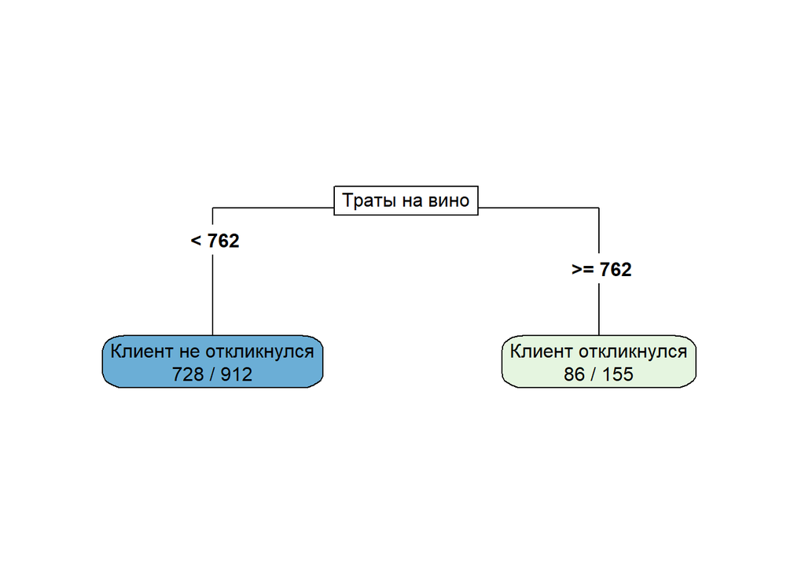

```r
### Отрежем дерево по оптимальному cp = 0.018519
set.seed(999999)
derevo5 = prune(derevo3, cp = 0.018519)
rpart.plot(derevo5, extra = 2, type = 5)
```

```r
set.seed(999999)
derevo4 <- rpart(`Отклик на кампанию` ~ `Траты на вино` +  `Доля покупок по скидкам` + `Семейное положение`, method = "class", data = marketing3_train, cp = 0.018519)
```

```r
pred3 = predict(derevo4, type="class", marketing3 = marketing3_train)


##Считаем accuracy на обучающей выборке
t = table(pred3, marketing3_train$`Отклик на кампанию`)
 (t[1,1] + t[2,2])/sum(t)
```

```
## [1] 0.7628866
```

```r
pred3_test = predict(derevo4, newdata = marketing3_test, type="class")

### Считаем Accuracy на тестовой выборке
z = table(pred3_test, marketing3_test$`Отклик на кампанию`)
(z[1,1] + z[2,2])/sum(z)
```

```
## [1] 0.7902622
```